# Insights from Loan_Data by Prosper

## by Koketso Diale

## Investigation Overview

*Key insights*

> Prospect's Rating score favors property owners, people with a stable source of income and higher credit balances, in the exploration it was thought that this was due to longer employment durations instead of employment status.

## Dataset Overview

This study Explored the Loan Data by Prosper dataset which contain various finance related data and features that relate to the loan application process at Prosper.

## Distribution of ProsperRating(Alpha) vs AvailableBankcardCredit with EmploymentStatus as legend.

> This graph shows the distribution of Borrowers against their ratings. Through this we can see that the AA tier mostly consists of Employed persons with a high AvailableBankcardCredit.

> Notice the positional encoding indicate rankings.

[figure not shown]

## Distribution of `States by Prosper Rating`

Heatmap of `BorrowerState vs ProsperRating (Alpha).`

> This visual plots the Borrower's frequency by State and indicates the count of each ProsperRating (Alpha) for the States.

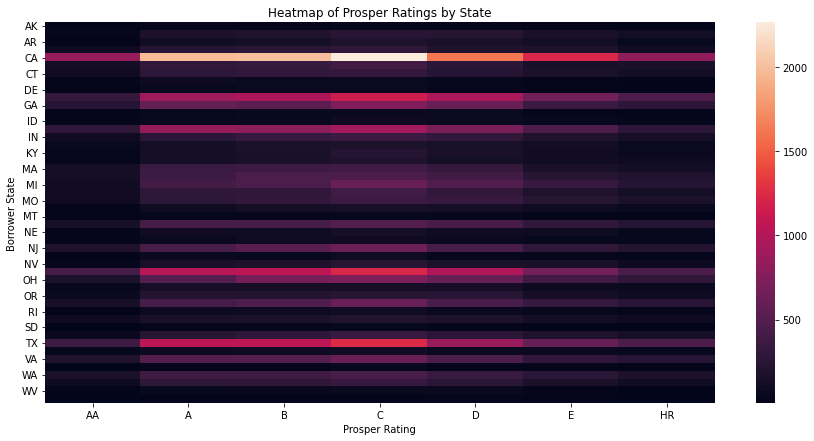

## Relational plot of IsHomeOwner vs Employment Duration.

> This Box plot indicating the relationship between EmploymentDuration & ProsperRating between Borrowers who are home owners and those who are None Home owners with Prosper Rating as a legend.

> The higher placement of the box plots of the home owners indicate how much longer most of them have been currently employed.

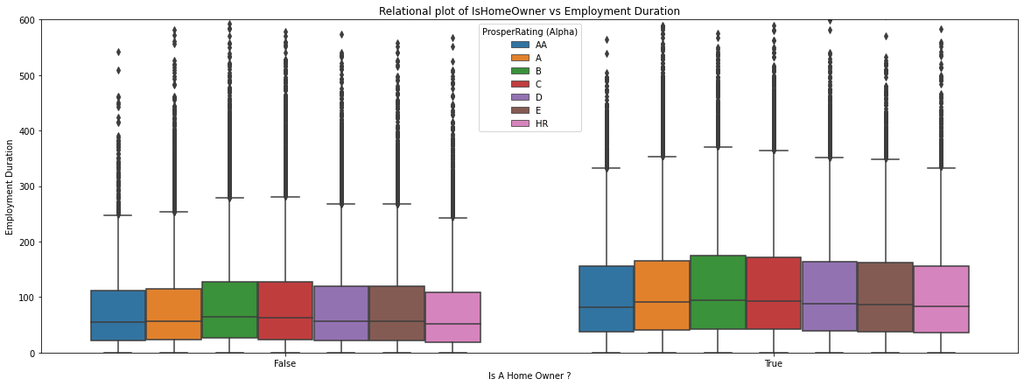

[output not shown]